# Lab 9 Avoiding Overfitting by Saving a Model

```python
import numpy as np
import pandas as pd
import matplotlib.pyplot as plt
import seaborn as sns
from tensorflow.keras.models import Sequential
from tensorflow.keras.layers import Dense
from tensorflow.keras.utils import to_categorical
from sklearn.model_selection import train_test_split
from sklearn.metrics import confusion_matrix
from tensorflow.keras.callbacks import ModelCheckpoint
from tensorflow.keras.layers import Dropout
from keras.models import load_model
from sklearn.metrics import accuracy_score, precision_score, recall_score, f1_score
```

```python
#loading the test data
df_test= np.genfromtxt('fashion-mnist_test.csv', delimiter =',')
```

```python
df_test
```

```
array([[nan, nan, nan, ..., nan, nan, nan],
       [ 0.,  0.,  0., ...,  0.,  0.,  0.],
       [ 1.,  0.,  0., ...,  0.,  0.,  0.],
       ...,
       [ 8.,  0.,  0., ...,  0.,  1.,  0.],
       [ 8.,  0.,  1., ...,  0.,  0.,  0.],
       [ 1.,  0.,  0., ...,  0.,  0.,  0.]])
```

```python
# to check the shape of the data
df_test.shape
```

```
(10001, 785)
```

```python
#loading the train data
df_train = np.genfromtxt('fashion-mnist_train.csv', delimiter =',')
```

```python
df_train
```

```
array([[nan, nan, nan, ..., nan, nan, nan],
       [ 2.,  0.,  0., ...,  0.,  0.,  0.],
       [ 9.,  0.,  0., ...,  0.,  0.,  0.],
       ...,
       [ 8.,  0.,  0., ...,  0.,  0.,  0.],
       [ 8.,  0.,  0., ...,  0.,  0.,  0.],
       [ 7.,  0.,  0., ...,  0.,  0.,  0.]])
```

```python
# to check the shape of the data
df_train.shape
```

```
(60001, 785)
```

```python
# Extract labels and pixel values
train_labels = df_train[:, 0]
test_labels = df_test[:, 0]
train_pixels = df_train[:, 1:]
test_pixels = df_test[:, 1:]
```

```python
# Remove rows with NaN values
train_non_nan = ~np.isnan(train_labels)
test_non_nan= ~np.isnan(test_labels)
```

```python
train_labels = train_labels[train_non_nan]
train_pixels = train_pixels[train_non_nan]
test_labels = test_labels[test_non_nan]
test_pixels = test_pixels[test_non_nan]
```

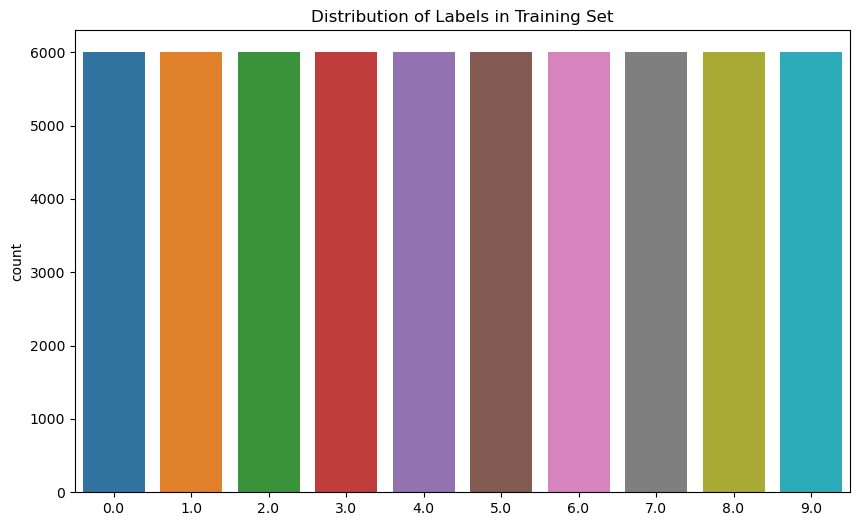

```python
# Distribution of labels in training set
plt.figure(figsize=(10, 6))
sns.countplot(x=train_labels)
plt.title('Distribution of Labels in Training Set')
plt.show()
```

The above shows the count distribution of each individual labels in the training set.

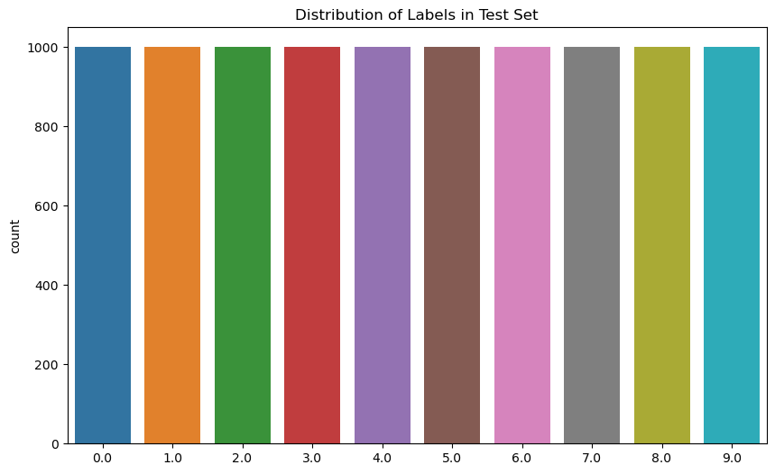

```python
# Distribution of labels in test set
plt.figure(figsize=(10, 6))
sns.countplot(x=test_labels)
plt.title('Distribution of Labels in Test Set')
plt.show()
```

The above graph shows the count distribution of each individual labels in the test data.

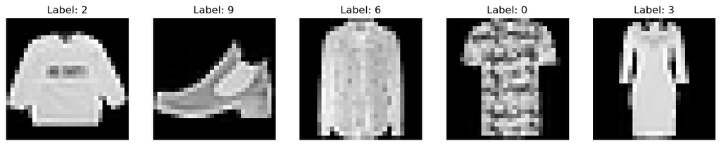

```python
# Display some sample images from the training set
num_samples = 5
plt.figure(figsize=(15, 5))
for i in range(num_samples):
    plt.subplot(1, num_samples, i + 1)
    plt.imshow(train_pixels[i].reshape(28, 28), cmap='gray')
    plt.title(f'Label: {int(train_labels[i])}')
    plt.axis('off')
plt.show()
```

The above visualization help us to understand the visual content on which the machine learning model will be trained on.

For reference: [For more information](https://matplotlib.org/stable/api/_as_gen/matplotlib.pyplot.subplot.html)

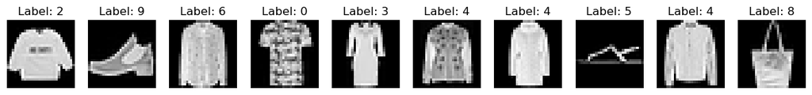

```python
# Display some sample images from the training set
num_samples = 10
plt.figure(figsize=(15, 5))
for i in range(num_samples):
    plt.subplot(1, num_samples, i + 1)
    plt.imshow(train_pixels[i].reshape(28, 28), cmap='gray')
    plt.title(f'Label: {int(train_labels[i])}')
    plt.axis('off')
plt.show()
```

The above visualization helps us to identified different labels:

- 9: ankle boot
- 6: shirt
- 0: t-shirt/top
- 8: bag

```python
# Normalize pixel values to be between 0 and 1
train_pixels = train_pixels / 255.0
test_pixels = test_pixels / 255.0
```

```python
# Convert labels to one-hot encoding
train_labels_one_hot = to_categorical(train_labels, num_classes=10)
test_labels_one_hot = to_categorical(test_labels, num_classes=10)
```

```python
# Split the training data into training and validation sets
X_train, X_val, y_train, y_val = train_test_split(train_pixels, train_labels_one_hot, test_size=0.2, random_state=42)
```

```python
# Define the neural network model
model_option = Sequential()
model_option.add(Dense(128, input_dim=784, activation='relu'))
model_option.add(Dense(64, activation='relu'))
model_option.add(Dense(10, activation='softmax'))
```

- Here we are using the sequential neural network model, the model stacks layers sequentially, where the output of one layer becomes the input of the next. Reference:[For more information](https://www.tensorflow.org/guide/keras)

```python
# Compile the model
model_option.compile(optimizer='adam', loss='categorical_crossentropy', metrics=['accuracy'])
```

```python
# Train the model
history_option = model_option.fit(X_train, y_train, epochs=10, batch_size=64, validation_data=(X_val, y_val))
```

```
750/750 ━━━━━━━━━━━━━━━━━━━━ 2s 2ms/step - accuracy: 0.7521 - loss: 0.7269 - val_accuracy: 0.8517 - val_loss: 0.4179
750/750 ━━━━━━━━━━━━━━━━━━━━ 1s 2ms/step - accuracy: 0.8536 - loss: 0.4086 - val_accuracy: 0.8522 - val_loss: 0.3974
750/750 ━━━━━━━━━━━━━━━━━━━━ 1s 2ms/step - accuracy: 0.8688 - loss: 0.3624 - val_accuracy: 0.8684 - val_loss: 0.3489
750/750 ━━━━━━━━━━━━━━━━━━━━ 1s 2ms/step - accuracy: 0.8769 - loss: 0.3361 - val_accuracy: 0.8737 - val_loss: 0.3562
750/750 ━━━━━━━━━━━━━━━━━━━━ 1s 2ms/step - accuracy: 0.8881 - loss: 0.3078 - val_accuracy: 0.8787 - val_loss: 0.3312
750/750 ━━━━━━━━━━━━━━━━━━━━ 1s 2ms/step - accuracy: 0.8906 - loss: 0.3002 - val_accuracy: 0.8827 - val_loss: 0.3205
750/750 ━━━━━━━━━━━━━━━━━━━━ 1s 2ms/step - accuracy: 0.8972 - loss: 0.2806 - val_accuracy: 0.8652 - val_loss: 0.3571
750/750 ━━━━━━━━━━━━━━━━━━━━ 2s 2ms/step - accuracy: 0.8991 - loss: 0.2673 - val_accuracy: 0.8842 - val_loss: 0.3129
750/750 ━━━━━━━━━━━━━━━━━━━━ 1s 2ms/step - accuracy: 0.9067 - loss: 0.2541 - val_accuracy: 0.8823 - val_loss: 0.3175
750/750 ━━━━━━━━━━━━━━━━━━━━ 1s 2ms/step - accuracy: 0.9084 - loss: 0.2462 - val_accuracy: 0.8918 - val_loss: 0.3071
```

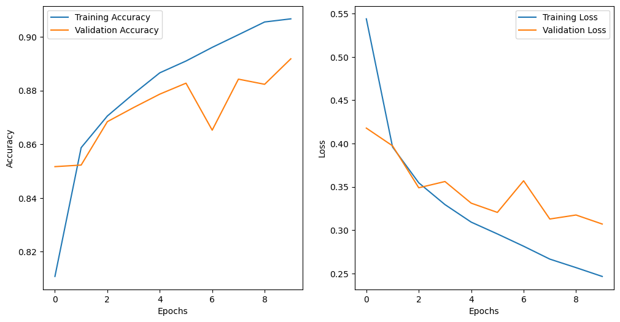

```python
# Plot the training history
plt.figure(figsize=(12, 6))
plt.subplot(1, 2, 1)
plt.plot(history_option.history['accuracy'], label='Training Accuracy')
plt.plot(history_option.history['val_accuracy'], label='Validation Accuracy')
plt.xlabel('Epochs')
plt.ylabel('Accuracy')
plt.legend()

plt.subplot(1, 2, 2)
plt.plot(history_option.history['loss'], label='Training Loss')
plt.plot(history_option.history['val_loss'], label='Validation Loss')
plt.xlabel('Epochs')
plt.ylabel('Loss')
plt.legend()

plt.show()
```

The left graph represents the Accuracy plot.

- Where the blue lines shows the model's accuracy on the training data after each epoch.
- The orange lines shows the model's accuracy on the validation data after each epoch.

The right graph represents the Loss plot.

- The blue lines shows the loss value calculated on the training data after each epoch.
- The Orange lines shows the loss value calculated on the validation data after each epoch.

** The plots in the image suggest that your neural network model is learning and improving its performance over the training epochs. The model's accuracy on the training data is increasing, and it's also performing well on the validation data, indicating some level of generalization.

For reference: [For more information](https://www.tensorflow.org/api_docs/python/tf/keras/Model)

```python
# Define the neural network model with more layers and neurons
model_option1 = Sequential()
model_option1.add(Dense(256, input_dim=784, activation='relu'))
model_option1.add(Dense(128, activation='relu'))
model_option1.add(Dense(64, activation='relu'))
model_option1.add(Dense(10, activation='softmax'))
```

```python
# Compile the model
model_option1.compile(optimizer='adam', loss='categorical_crossentropy', metrics=['accuracy'])
```

```python
# Train the model
history_option1 = model_option1.fit(X_train, y_train, epochs=10, batch_size=64, validation_data=(X_val, y_val))
```

```
750/750 ━━━━━━━━━━━━━━━━━━━━ 3s 2ms/step - accuracy: 0.7523 - loss: 0.7048 - val_accuracy: 0.8504 - val_loss: 0.4096
750/750 ━━━━━━━━━━━━━━━━━━━━ 2s 3ms/step - accuracy: 0.8606 - loss: 0.3901 - val_accuracy: 0.8653 - val_loss: 0.3655
750/750 ━━━━━━━━━━━━━━━━━━━━ 2s 2ms/step - accuracy: 0.8759 - loss: 0.3453 - val_accuracy: 0.8638 - val_loss: 0.3746
750/750 ━━━━━━━━━━━━━━━━━━━━ 2s 2ms/step - accuracy: 0.8822 - loss: 0.3173 - val_accuracy: 0.8784 - val_loss: 0.3362
750/750 ━━━━━━━━━━━━━━━━━━━━ 2s 3ms/step - accuracy: 0.8878 - loss: 0.3024 - val_accuracy: 0.8828 - val_loss: 0.3436
750/750 ━━━━━━━━━━━━━━━━━━━━ 2s 3ms/step - accuracy: 0.8955 - loss: 0.2751 - val_accuracy: 0.8798 - val_loss: 0.3231
750/750 ━━━━━━━━━━━━━━━━━━━━ 2s 3ms/step - accuracy: 0.9020 - loss: 0.2641 - val_accuracy: 0.8852 - val_loss: 0.3125
750/750 ━━━━━━━━━━━━━━━━━━━━ 2s 3ms/step - accuracy: 0.9024 - loss: 0.2590 - val_accuracy: 0.8858 - val_loss: 0.3097
750/750 ━━━━━━━━━━━━━━━━━━━━ 2s 2ms/step - accuracy: 0.9097 - loss: 0.2446 - val_accuracy: 0.8863 - val_loss: 0.3297
750/750 ━━━━━━━━━━━━━━━━━━━━ 2s 2ms/step - accuracy: 0.9099 - loss: 0.2362 - val_accuracy: 0.8896 - val_loss: 0.3192
```

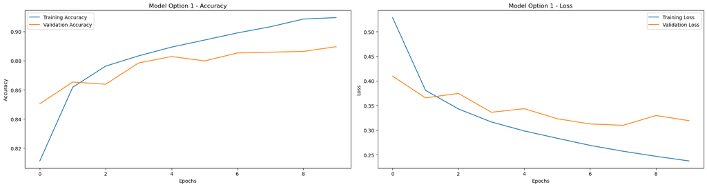

```python
plt.figure(figsize=(20, 15))

# Model option 1
plt.subplot(3, 2, 1)
plt.plot(history_option1.history['accuracy'], label='Training Accuracy')
plt.plot(history_option1.history['val_accuracy'], label='Validation Accuracy')
plt.xlabel('Epochs')
plt.ylabel('Accuracy')
plt.title('Model Option 1 - Accuracy')
plt.legend()


#model option 1
plt.subplot(3, 2, 2)
plt.plot(history_option1.history['loss'], label='Training Loss')
plt.plot(history_option1.history['val_loss'], label='Validation Loss')
plt.xlabel('Epochs')
plt.ylabel('Loss')
plt.title('Model Option 1 - Loss')
plt.legend()

plt.tight_layout()
plt.show()
```

For the Left graph:

- The two lines on the left-hand side of the graph show the training accuracy and validation accuracy of the model.
- The training accuracy is generally higher than the validation accuracy, which is a sign that the model is overfitting the training data.

For the right graph:

- The two lines on the right-hand side of the graph show the training loss and validation loss of the model.
- The training loss and validation loss have both decreased over time, which is a good sign. This suggests that the model is learning from the training data.

Overall, the graph shows that the model is making some progress on the training data.

For reference: [For more information](https://www.tensorflow.org/api_docs/python/tf/keras/Model)

```python
# Define the neural network model with tanh activation
model_option2 = Sequential()
model_option2.add(Dense(128, input_dim=784, activation='tanh'))
model_option2.add(Dense(64, activation='tanh'))
model_option2.add(Dense(10, activation='softmax'))
```

```python
# Compile the model
model_option2.compile(optimizer='adam', loss='categorical_crossentropy', metrics=['accuracy'])
```

```python
# Train the model
history_option2 = model_option2.fit(X_train, y_train, epochs=10, batch_size=64, validation_data=(X_val, y_val))
```

```
750/750 ━━━━━━━━━━━━━━━━━━━━ 2s 2ms/step - accuracy: 0.7680 - loss: 0.6759 - val_accuracy: 0.8490 - val_loss: 0.4166
750/750 ━━━━━━━━━━━━━━━━━━━━ 1s 2ms/step - accuracy: 0.8591 - loss: 0.3901 - val_accuracy: 0.8493 - val_loss: 0.3987
750/750 ━━━━━━━━━━━━━━━━━━━━ 1s 2ms/step - accuracy: 0.8738 - loss: 0.3456 - val_accuracy: 0.8678 - val_loss: 0.3607
750/750 ━━━━━━━━━━━━━━━━━━━━ 2s 2ms/step - accuracy: 0.8858 - loss: 0.3190 - val_accuracy: 0.8759 - val_loss: 0.3396
750/750 ━━━━━━━━━━━━━━━━━━━━ 2s 2ms/step - accuracy: 0.8897 - loss: 0.2999 - val_accuracy: 0.8823 - val_loss: 0.3199
750/750 ━━━━━━━━━━━━━━━━━━━━ 2s 2ms/step - accuracy: 0.8949 - loss: 0.2872 - val_accuracy: 0.8793 - val_loss: 0.3249
750/750 ━━━━━━━━━━━━━━━━━━━━ 2s 2ms/step - accuracy: 0.8998 - loss: 0.2724 - val_accuracy: 0.8824 - val_loss: 0.3148
750/750 ━━━━━━━━━━━━━━━━━━━━ 2s 2ms/step - accuracy: 0.9044 - loss: 0.2599 - val_accuracy: 0.8832 - val_loss: 0.3261
750/750 ━━━━━━━━━━━━━━━━━━━━ 1s 2ms/step - accuracy: 0.9056 - loss: 0.2583 - val_accuracy: 0.8773 - val_loss: 0.3290
750/750 ━━━━━━━━━━━━━━━━━━━━ 1s 2ms/step - accuracy: 0.9118 - loss: 0.2407 - val_accuracy: 0.8785 - val_loss: 0.3197
```

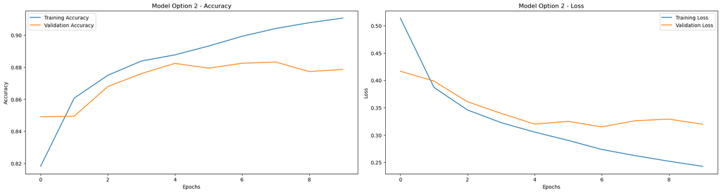

```python
plt.figure(figsize=(20, 15))

# Model option 2
plt.subplot(3, 2, 3)
plt.plot(history_option2.history['accuracy'], label='Training Accuracy')
plt.plot(history_option2.history['val_accuracy'], label='Validation Accuracy')
plt.xlabel('Epochs')
plt.ylabel('Accuracy')
plt.title('Model Option 2 - Accuracy')
plt.legend()

#model option 2
plt.subplot(3, 2, 4)
plt.plot(history_option2.history['loss'], label='Training Loss')
plt.plot(history_option2.history['val_loss'], label='Validation Loss')
plt.xlabel('Epochs')
plt.ylabel('Loss')
plt.title('Model Option 2 - Loss')
plt.legend()

plt.tight_layout()
plt.show()
```

For the left graph:

- The training accuracy is generally higher than the validation accuracy, which is a sign that the model is overfitting the training data.

For the right graph:

- The two lines on the right-hand side of the graph show the training loss and validation loss of the model. The training loss and validation loss have both decreased over time, which is a good sign.

For reference: [For more information](https://www.tensorflow.org/api_docs/python/tf/keras/Model)

```python
# Define the neural network model with dropout
model_option3 = Sequential()
model_option3.add(Dense(128, input_dim=784, activation='relu'))
model_option3.add(Dropout(0.2))  # Dropout layer with 20% dropout rate
model_option3.add(Dense(64, activation='relu'))
model_option3.add(Dense(10, activation='softmax'))
```

```python
# Compile the model
model_option3.compile(optimizer='adam', loss='categorical_crossentropy', metrics=['accuracy'])
```

```python
# Train the model
history_option3 = model_option3.fit(X_train, y_train, epochs=10, batch_size=64, validation_data=(X_val, y_val))
```

```
750/750 ━━━━━━━━━━━━━━━━━━━━ 2s 2ms/step - accuracy: 0.7301 - loss: 0.7836 - val_accuracy: 0.8482 - val_loss: 0.4127
750/750 ━━━━━━━━━━━━━━━━━━━━ 1s 2ms/step - accuracy: 0.8449 - loss: 0.4294 - val_accuracy: 0.8561 - val_loss: 0.3936
750/750 ━━━━━━━━━━━━━━━━━━━━ 2s 2ms/step - accuracy: 0.8592 - loss: 0.3883 - val_accuracy: 0.8665 - val_loss: 0.3692
750/750 ━━━━━━━━━━━━━━━━━━━━ 2s 3ms/step - accuracy: 0.8680 - loss: 0.3615 - val_accuracy: 0.8621 - val_loss: 0.3635
750/750 ━━━━━━━━━━━━━━━━━━━━ 2s 3ms/step - accuracy: 0.8713 - loss: 0.3518 - val_accuracy: 0.8742 - val_loss: 0.3331
750/750 ━━━━━━━━━━━━━━━━━━━━ 2s 3ms/step - accuracy: 0.8762 - loss: 0.3348 - val_accuracy: 0.8726 - val_loss: 0.3370
750/750 ━━━━━━━━━━━━━━━━━━━━ 2s 3ms/step - accuracy: 0.8791 - loss: 0.3291 - val_accuracy: 0.8785 - val_loss: 0.3389
750/750 ━━━━━━━━━━━━━━━━━━━━ 3s 3ms/step - accuracy: 0.8853 - loss: 0.3148 - val_accuracy: 0.8792 - val_loss: 0.3213
750/750 ━━━━━━━━━━━━━━━━━━━━ 2s 3ms/step - accuracy: 0.8860 - loss: 0.3052 - val_accuracy: 0.8805 - val_loss: 0.3304
750/750 ━━━━━━━━━━━━━━━━━━━━ 2s 3ms/step - accuracy: 0.8875 - loss: 0.3033 - val_accuracy: 0.8873 - val_loss: 0.3172
```

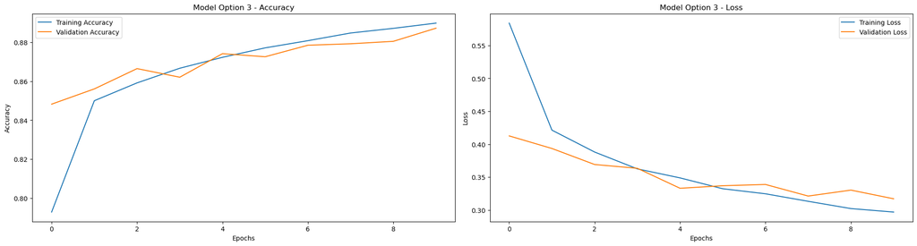

```python
plt.figure(figsize=(20, 15))
# Model option 3
plt.subplot(3, 2, 5)
plt.plot(history_option3.history['accuracy'], label='Training Accuracy')
plt.plot(history_option3.history['val_accuracy'], label='Validation Accuracy')
plt.xlabel('Epochs')
plt.ylabel('Accuracy')
plt.title('Model Option 3 - Accuracy')
plt.legend()

#model option 3
plt.subplot(3, 2, 6)
plt.plot(history_option3.history['loss'], label='Training Loss')
plt.plot(history_option3.history['val_loss'], label='Validation Loss')
plt.xlabel('Epochs')
plt.ylabel('Loss')
plt.title('Model Option 3 - Loss')
plt.legend()

plt.tight_layout()
plt.show()
```

For the right graph:

- The graph show the training loss and validation loss of the model. Ideally, the training loss and validation loss would both decrease over time.

For reference: [For more information](https://www.tensorflow.org/api_docs/python/tf/keras/Model)

##### For Model Option(Original)

- Around epoch 8 or 9 appears to be the best epoch for this model

##### For Model Option 1

- Around epoch 8 or 9 seems to be the best epoch where both accuracy and loss stabilize.

##### For Model Option 3

- Around epoch 8 or 9 seems to be the best epoch where both accuracy and loss stabilize.

##### Model option 2:

- The training accuracy improves to around 91.2%, while the validation accuracy stabilizes around 88.4%.
- However, there is a slight increase in validation loss towards the end, indicating potential early signs of overfitting.

#### Conclusion:

```python
# Define the checkpoint filepath
checkpoint_filepath = 'best_model_option1.keras'
```

```python
# Define the ModelCheckpoint callback
model_checkpoint_callback = ModelCheckpoint(
    filepath=checkpoint_filepath,
    save_weights_only=False,
    monitor='val_loss',
    mode='min',
    save_best_only=True)
```

For reference:[For more information](https://github.com/CSCN8010/CSCN8010/blob/main/dl_class_notebooks/03D_keras_checkpoints_save_model.ipynb)

```python
# Train your model defined with model_option1
history_option1 = model_option1.fit(
    X_train, y_train,
    epochs=20,
    batch_size=64,
    validation_data=(X_val, y_val),
    callbacks=[model_checkpoint_callback])
```

```
750/750 ━━━━━━━━━━━━━━━━━━━━ 3s 4ms/step - accuracy: 0.9139 - loss: 0.2276 - val_accuracy: 0.8918 - val_loss: 0.3037
750/750 ━━━━━━━━━━━━━━━━━━━━ 3s 3ms/step - accuracy: 0.9169 - loss: 0.2175 - val_accuracy: 0.8881 - val_loss: 0.3288
750/750 ━━━━━━━━━━━━━━━━━━━━ 3s 3ms/step - accuracy: 0.9190 - loss: 0.2134 - val_accuracy: 0.8878 - val_loss: 0.3309
750/750 ━━━━━━━━━━━━━━━━━━━━ 3s 3ms/step - accuracy: 0.9239 - loss: 0.2000 - val_accuracy: 0.8943 - val_loss: 0.3218
750/750 ━━━━━━━━━━━━━━━━━━━━ 3s 4ms/step - accuracy: 0.9264 - loss: 0.1949 - val_accuracy: 0.8873 - val_loss: 0.3321
750/750 ━━━━━━━━━━━━━━━━━━━━ 3s 4ms/step - accuracy: 0.9275 - loss: 0.1891 - val_accuracy: 0.8927 - val_loss: 0.3221
750/750 ━━━━━━━━━━━━━━━━━━━━ 3s 4ms/step - accuracy: 0.9310 - loss: 0.1787 - val_accuracy: 0.8876 - val_loss: 0.3224
750/750 ━━━━━━━━━━━━━━━━━━━━ 3s 4ms/step - accuracy: 0.9302 - loss: 0.1825 - val_accuracy: 0.8946 - val_loss: 0.3253
750/750 ━━━━━━━━━━━━━━━━━━━━ 3s 4ms/step - accuracy: 0.9363 - loss: 0.1699 - val_accuracy: 0.8949 - val_loss: 0.3424
750/750 ━━━━━━━━━━━━━━━━━━━━ 3s 4ms/step - accuracy: 0.9362 - loss: 0.1678 - val_accuracy: 0.8909 - val_loss: 0.3383
750/750 ━━━━━━━━━━━━━━━━━━━━ 3s 3ms/step - accuracy: 0.9416 - loss: 0.1538 - val_accuracy: 0.8978 - val_loss: 0.3413
750/750 ━━━━━━━━━━━━━━━━━━━━ 3s 3ms/step - accuracy: 0.9399 - loss: 0.1555 - val_accuracy: 0.8971 - val_loss: 0.3453
750/750 ━━━━━━━━━━━━━━━━━━━━ 3s 3ms/step - accuracy: 0.9426 - loss: 0.1485 - val_accuracy: 0.8952 - val_loss: 0.3684
750/750 ━━━━━━━━━━━━━━━━━━━━ 3s 3ms/step - accuracy: 0.9427 - loss: 0.1500 - val_accuracy: 0.8968 - val_loss: 0.3692
750/750 ━━━━━━━━━━━━━━━━━━━━ 2s 3ms/step - accuracy: 0.9454 - loss: 0.1407 - val_accuracy: 0.8952 - val_loss: 0.3644
750/750 ━━━━━━━━━━━━━━━━━━━━ 2s 2ms/step - accuracy: 0.9468 - loss: 0.1356 - val_accuracy: 0.8924 - val_loss: 0.3835
750/750 ━━━━━━━━━━━━━━━━━━━━ 2s 2ms/step - accuracy: 0.9496 - loss: 0.1301 - val_accuracy: 0.8924 - val_loss: 0.4026
750/750 ━━━━━━━━━━━━━━━━━━━━ 2s 2ms/step - accuracy: 0.9510 - loss: 0.1283 - val_accuracy: 0.8879 - val_loss: 0.3953
750/750 ━━━━━━━━━━━━━━━━━━━━ 2s 2ms/step - accuracy: 0.9515 - loss: 0.1250 - val_accuracy: 0.8923 - val_loss: 0.4285
750/750 ━━━━━━━━━━━━━━━━━━━━ 2s 3ms/step - accuracy: 0.9535 - loss: 0.1217 - val_accuracy: 0.8938 - val_loss: 0.4094
```

```python
#loading the best model
best_model = load_model('best_model_option1.keras')
best_model
```

```
<Sequential name=sequential_1, built=True>
```

### Note: make changes to the previous lab 8 code snippet based on the best model selection from the different approach.

### In this case the best option.

```python
# Evaluate the model option 1 on the test set
test_loss, test_acc = best_model.evaluate(test_pixels, test_labels_one_hot)
print(f'Test Accuracy: {test_acc * 100:.2f}%')
```

```
313/313 ━━━━━━━━━━━━━━━━━━━━ 1s 1ms/step - accuracy: 0.8859 - loss: 0.3145
Test Accuracy: 89.36%
```

```python
# Predictions on the validation set
y_val_pred_prob = best_model.predict(X_val)
y_val_pred = np.argmax(y_val_pred_prob, axis=1)
```

```
375/375 ━━━━━━━━━━━━━━━━━━━━ 0s 1ms/step
```

```python
# Convert one-hot encoded labels back to categorical labels
y_val_true = np.argmax(y_val, axis=1)
```

```python
# Calculate metrics
accuracy = accuracy_score(y_val_true, y_val_pred)
precision = precision_score(y_val_true, y_val_pred, average='weighted')
recall = recall_score(y_val_true, y_val_pred, average='weighted')
f1 = f1_score(y_val_true, y_val_pred, average='weighted')
```

```python
# Print the metrics
print(f'Validation Accuracy: {accuracy * 100:.2f}%')
print(f'Validation Precision: {precision:.2f}')
print(f'Validation Recall: {recall:.2f}')
print(f'Validation F1 Score: {f1:.2f}')
```

```
Validation Accuracy: 89.18%
Validation Precision: 0.89
Validation Recall: 0.89
Validation F1 Score: 0.89
```

```python
# Confusion matrix
conf_mat = confusion_matrix(y_val_true, y_val_pred)
conf_mat
```

```
array([[1113,    2,   16,   21,    3,    0,   75,    0,    2,    0],
       [   1, 1141,    1,   27,    2,    0,    1,    0,    1,    0],
       [  18,    1,  995,   13,  134,    0,   35,    0,    4,    0],
       [  43,    9,    6, 1108,   59,    0,   15,    0,    2,    0],
       [   5,    2,   71,   37, 1028,    0,   38,    0,    4,    0],
       [   1,    0,    0,    0,    0, 1095,    0,   25,    3,   17],
       [ 194,    1,  120,   22,  127,    0,  768,    0,   10,    1],
       [   0,    0,    0,    0,    0,   26,    0, 1139,    3,   56],
       [   9,    1,    1,    1,    4,    0,    3,    1, 1129,    0],
       [   0,    0,    0,    0,    0,    4,    0,   19,    1, 1186]],
      dtype=int64)
```

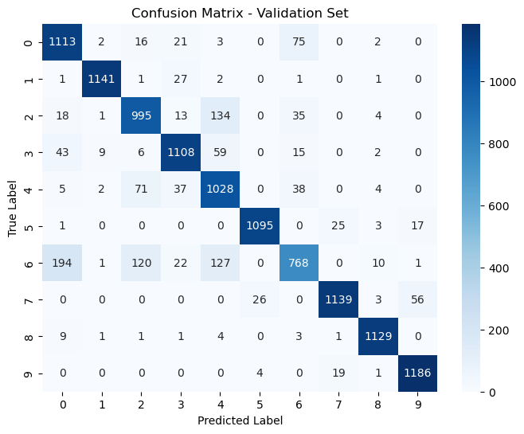

```python
# Plot heatmap
plt.figure(figsize=(8, 6))
sns.heatmap(conf_mat, annot=True, fmt='d', cmap='Blues', xticklabels=np.unique(y_val_true), yticklabels=np.unique(y_val_true))
plt.title('Confusion Matrix - Validation Set')
plt.xlabel('Predicted Label')
plt.ylabel('True Label')
plt.show()
```

```python
# Predictions on the test set
y_test_pred_prob = best_model.predict(test_pixels)
y_test_pred = np.argmax(y_test_pred_prob, axis=1)
```

```
313/313 ━━━━━━━━━━━━━━━━━━━━ 0s 1ms/step
```

```python
# Convert one-hot encoded labels back to categorical labels
y_test_true = np.argmax(test_labels_one_hot, axis=1)
```

```python
# Calculate metrics
test_accuracy = accuracy_score(y_test_true, y_test_pred)
test_precision = precision_score(y_test_true, y_test_pred, average='weighted')
test_recall = recall_score(y_test_true, y_test_pred, average='weighted')
test_f1 = f1_score(y_test_true, y_test_pred, average='weighted')
```

```python
# Print the metrics on the test set
print(f'Test Accuracy: {test_accuracy * 100:.2f}%')
print(f'Test Precision: {test_precision:.2f}')
print(f'Test Recall: {test_recall:.2f}')
print(f'Test F1 Score: {test_f1:.2f}')
```

```
Test Accuracy: 89.36%
Test Precision: 0.90
Test Recall: 0.89
Test F1 Score: 0.89
```

```python
# Confusion matrix on the test set
conf_mat_test = confusion_matrix(y_test_true, y_test_pred)
conf_mat_test
```

```
array([[899,   0,  19,  13,   0,   1,  62,   0,   6,   0],
       [  3, 981,   3,  11,   0,   0,   1,   0,   1,   0],
       [ 19,   0, 821,   5, 113,   0,  38,   0,   4,   0],
       [ 27,   8,  15, 897,  36,   1,  14,   0,   2,   0],
       [  1,   0,  54,  19, 898,   0,  28,   0,   0,   0],
       [  0,   0,   1,   0,   0, 946,   0,  25,   3,  25],
       [181,   0,  86,  12,  95,   0, 618,   0,   8,   0],
       [  0,   0,   0,   0,   0,  17,   0, 917,   1,  65],
       [  4,   0,   7,   1,   2,   1,   3,   2, 978,   2],
       [  0,   0,   0,   0,   0,   3,   0,  16,   0, 981]], dtype=int64)
```

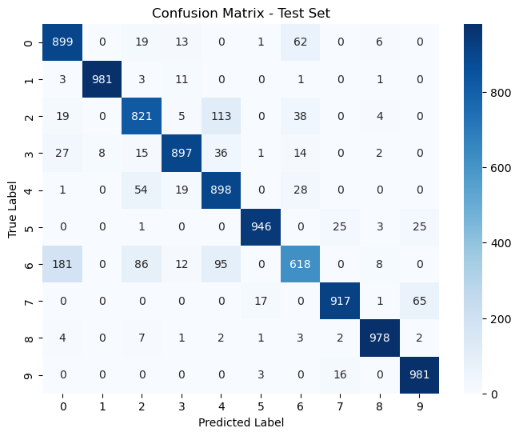

```python
# Plot heatmap for the confusion matrix on the test set
plt.figure(figsize=(8, 6))
sns.heatmap(conf_mat_test, annot=True, fmt='d', cmap='Blues', xticklabels=np.unique(y_test_true), yticklabels=np.unique(y_test_true))
plt.title('Confusion Matrix - Test Set')
plt.xlabel('Predicted Label')
plt.ylabel('True Label')
plt.show()
```

```python
#choosing a higher threshold for the class '5'
threshold = 0.7
```

Increasing the threshold might increase precision but could decrease recall, so it's a trade-off.

```python
# Adjust predictions based on the threshold for class '5'
y_val_pred_class5 = (y_val_pred_prob[:, 5] > threshold).astype(int)
```

```python
# Print the original and adjusted counts for class '5'
print(f"Original Predictions for class '5': {np.sum(y_val_pred == 5)}")
print(f"Adjusted Predictions for class '5' with threshold {threshold}: {np.sum(y_val_pred_class5)}")
```

```
Original Predictions for class '5': 1125
Adjusted Predictions for class '5' with threshold 0.7: 1107
```

```python
# Calculate adjusted precision for class '5' with zero_division parameter
adjusted_precision_class5 = precision_score(y_val_true, y_val_pred_class5, labels=[5], average='weighted', zero_division=1)

# Print the adjusted precision
print(f'Adjusted Precision for class "5": {adjusted_precision_class5:.2f}')
```

```
Adjusted Precision for class "5": 1.00
```

```python
# Choosing a lower threshold for classifying class '5'
new_threshold = 0.3
```

```python
# Adjust predictions based on the new threshold for class '5'
y_val_pred_class5_new = (y_val_pred_prob[:, 5] > new_threshold).astype(int)
```

```python
# Print the original and adjusted counts for class '5'
print(f"Original Predictions for class '5': {np.sum(y_val_pred == 5)}")
print(f"Adjusted Predictions for class '5' with threshold {new_threshold}: {np.sum(y_val_pred_class5_new)}")
```

```
Original Predictions for class '5': 1125
Adjusted Predictions for class '5' with threshold 0.3: 1137
```

```python
# Calculate adjusted recall for class '5' with zero_division parameter
adjusted_recall_class5 = recall_score(y_val_true, y_val_pred_class5_new, labels=[5], average='weighted', zero_division=1)

# Print the adjusted recall
print(f'Adjusted Recall for class "5": {adjusted_recall_class5:.2f}')
```

```
Adjusted Recall for class "5": 0.00
```